# Exp6_selectiveAnalysis_Feb2021

Mrudula

02 March,2021

# Memo for Exp6 Analysis with only outliers meant for the Kolloquium Talk on 10th Feb 2021

This memo entails the results and analysis after choosing one criteria for exclusion –> outliers and analysing and interpreting results with this criteria alone. This memo involves the following results

```
* Validity Main effect with learn trials
* Saliency Manipulation check with the selected manipulation trials
* Interaction between  Validity and Saliency for test trials
* Block analysis
* Overshadowing in binding trials
* Including ResponseType as a factor
* Exploratory Analysis with awareness
```

Loading the libraries

Loading the relevant libraries and the dataset

### Data preparation and cleaning

- Removing unnecessary columns
- Preparing the RT trial
- Creating a column for Accuracy and Error Rate

### Descriptives

Summary of the overall Reaction Time, accuracy and Error Rate

Mean RT

| Min. | 1st Qu. | Median | Mean | 3rd Qu. | Max. |
| --- | --- | --- | --- | --- | --- |
| 0.675 | 457.2 | 541.8 | 571.7 | 640.2 | 11708 |

Accuracy

| 0 | 1 |
| --- | --- |
| 1529 | 27590 |

Percentage of errors

| 0 | 1 |
| --- | --- |
| 5.251 | 94.75 |

Removing the outliers and farouts * Outliers are identified excluded if they are 3x more than the third quartile * Farouts are identified excluded if they are 1.5x more than the third quartile * RTs less than 300ms

```
## [1] 1529
```

```
## [1] 2459
```

Summary of RT after removing Outliers

| Min. | 1st Qu. | Median | Mean | 3rd Qu. | Max. | NA’s |
| --- | --- | --- | --- | --- | --- | --- |
| 300.1 | 470.9 | 544.4 | 560.6 | 629.1 | 1583 | 4099 |

## ANALYSES

### 1. Validity Manipulation check - Learn trials

Valid trials are significantly faster than invalid trials with a mean difference of 17ms for outliers.

Table containing means of valid and invalid learn trials, outliers excluded

| Validity | RT_io |
| --- | --- |
| invalid | 574.4 |
| valid | 556.6 |

t test showing differences between valid and invalid trials-excluding outliers (continued below)

| Test statistic | df | P value | Alternative hypothesis |
| --- | --- | --- | --- |
| 6.028 | 69 | 7.275e-08 * * * | two.sided |

| mean of the differences |
| --- |
| 17.78 |

### 2. Saliency Manipulation Check

There is a significant difference between trials where the target appeared at the position of the salient letter vs target at the position of the non salient : Salient position is 23ms faster

```r
Exp6SalCheck_o <- aggregate(data = Exp6data, RT_io~participant+Saliency, subset = (Block == "SalMC"), mean)

pander(t.test(RT_io~Saliency, data = Exp6SalCheck_o,paired=TRUE),style = "rmarkdown", caption = "t test result for saliency manipulation, outliers")
```

t test result for saliency manipulation, outliers (continued below)

| Test statistic | df | P value | Alternative hypothesis |
| --- | --- | --- | --- |
| 2.365 | 68 | 0.02088 * | two.sided |

| mean of the differences |
| --- |
| 22.59 |

```r
sallearnplot <- ggplot(data = Exp6SalCheck_o, aes(x = factor(Saliency, level = c("Salient", "NonSalient")), y = RT_io, group = Saliency))+
  geom_line(aes(group = 1), stat = "summary", fun = "mean", color = "deepskyblue4", size = 1)+coord_cartesian(ylim = c(600,700))+
  geom_point(stat = "summary", fun = "mean", color = "deepskyblue4")+theme_classic()+ylab("ReactionTime")+xlab("Saliency")
ggsave(filename = here("Figures","salearneffect.png"), sallearnplot)
```

### 3. Interaction of Validity x Saliency in test trials

This analysis is the main one concerning overshadowing.

- **ANOVA**:

  | Effect | DFn | DFd | SSn | SSd | F | p | p<.05 | ges |
  | --- | --- | --- | --- | --- | --- | --- | --- | --- |
  | (Intercept) | 1 | 69 | 89163384 | 780030 | 7887 | 7.058e-73 | * | 0.9896 |
  | Validity | 1 | 69 | 9218 | 53197 | 11.96 | 0.0009373 | * | 0.00974 |
  | Saliency | 1 | 69 | 176.9 | 41339 | 0.2953 | 0.5886 |  | 0.0001887 |
  | Validity:Saliency | 1 | 69 | 58.06 | 62585 | 0.06401 | 0.801 |  | 6.194e-05 |

```
## $`--- ANOVA RESULTS     ------------------------------------`
##              Effect        MSE df1 df2       F     p petasq getasq
## 1       (Intercept) 11304.7815   1  69 7887.23 0.000   0.99   0.99
## 2          Validity   770.9676   1  69   11.96 0.001   0.15   0.01
## 3          Saliency   599.1103   1  69    0.30 0.589   0.00   0.00
## 4 Validity:Saliency   907.0347   1  69    0.06 0.801   0.00   0.00
##
## $`--- SPHERICITY TESTS  ------------------------------------`
## [1] "N/A"
##
## $`--- FORMATTED RESULTS ------------------------------------`
##              Effect                                    Text
## 1       (Intercept) F(1, 69) = 7887.23, p < .001, np2 = .99
## 2          Validity F(1, 69) =   11.96, p = .001, np2 = .15
## 3          Saliency F(1, 69) =    0.30, p = .589, np2 < .01
## 4 Validity:Saliency F(1, 69) =    0.06, p = .801, np2 < .01
##
## $`NOTE:`
## [1] "Reporting unadjusted p-values."
```

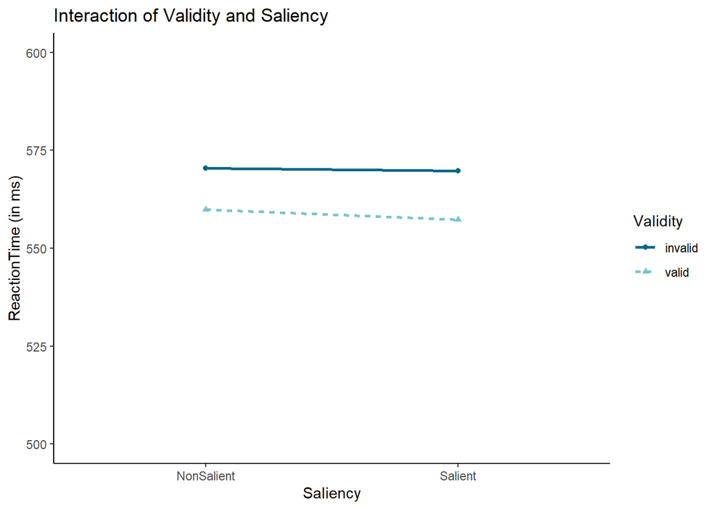

| Saliency | N | Mean | SD | FLSD |
| --- | --- | --- | --- | --- |
| NonSalient | 70 | 10.56 | 36.5 | 14.36 |
| Salient | 70 | 12.39 | 44.98 | 14.36 |

While comparing the validity effect for each type of saliency we find that it is significant for both the salient trials as well as the non salient trials

t test for validity effect for salient trials

| Test statistic | df | P value | Alternative hypothesis | mean of the differences |
| --- | --- | --- | --- | --- |
| 2.304 | 69 | 0.02426 * | two.sided | 12.39 |

| Test statistic | df | P value | Alternative hypothesis | mean of the differences |
| --- | --- | --- | --- | --- |
| 2.421 | 69 | 0.01809 * | two.sided | 10.56 |

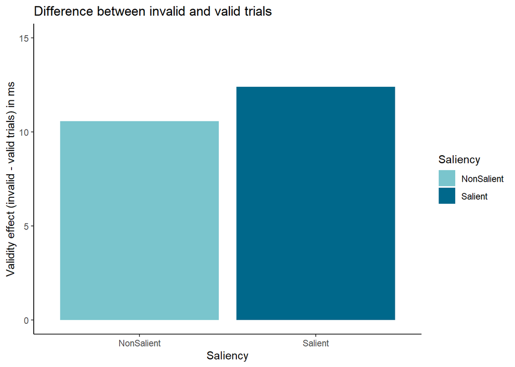

### 4. Error Rate

Maybe this could throw more light on expected associations and quick responses leading to errors - can it be concluded that learning and overshadowing was successful based on error rates??

- **ANOVA**:

  | Effect | DFn | DFd | SSn | SSd | F | p | p<.05 | ges |
  | --- | --- | --- | --- | --- | --- | --- | --- | --- |
  | (Intercept) | 1 | 69 | 1.082 | 0.6346 | 117.6 | 1.472e-16 | * | 0.4425 |
  | Saliency | 1 | 69 | 0.009203 | 0.1773 | 3.581 | 0.06263 |  | 0.006705 |
  | Validity | 1 | 69 | 0.02424 | 0.2473 | 6.764 | 0.01137 | * | 0.01747 |
  | Saliency:Validity | 1 | 69 | 0.01737 | 0.3042 | 3.94 | 0.05112 |  | 0.01258 |

```
## $`--- ANOVA RESULTS     ------------------------------------`
##              Effect         MSE df1 df2      F     p petasq getasq
## 1       (Intercept) 0.009196814   1  69 117.64 0.000   0.63   0.44
## 2          Saliency 0.002569811   1  69   3.58 0.063   0.05   0.01
## 3          Validity 0.003583759   1  69   6.76 0.011   0.09   0.02
## 4 Saliency:Validity 0.004407994   1  69   3.94 0.051   0.05   0.01
##
## $`--- SPHERICITY TESTS  ------------------------------------`
## [1] "N/A"
##
## $`--- FORMATTED RESULTS ------------------------------------`
##              Effect                                   Text
## 1       (Intercept) F(1, 69) = 117.64, p < .001, np2 = .63
## 2          Saliency F(1, 69) =   3.58, p = .063, np2 = .05
## 3          Validity F(1, 69) =   6.76, p = .011, np2 = .09
## 4 Saliency:Validity F(1, 69) =   3.94, p = .051, np2 = .05
##
## $`NOTE:`
## [1] "Reporting unadjusted p-values."
```

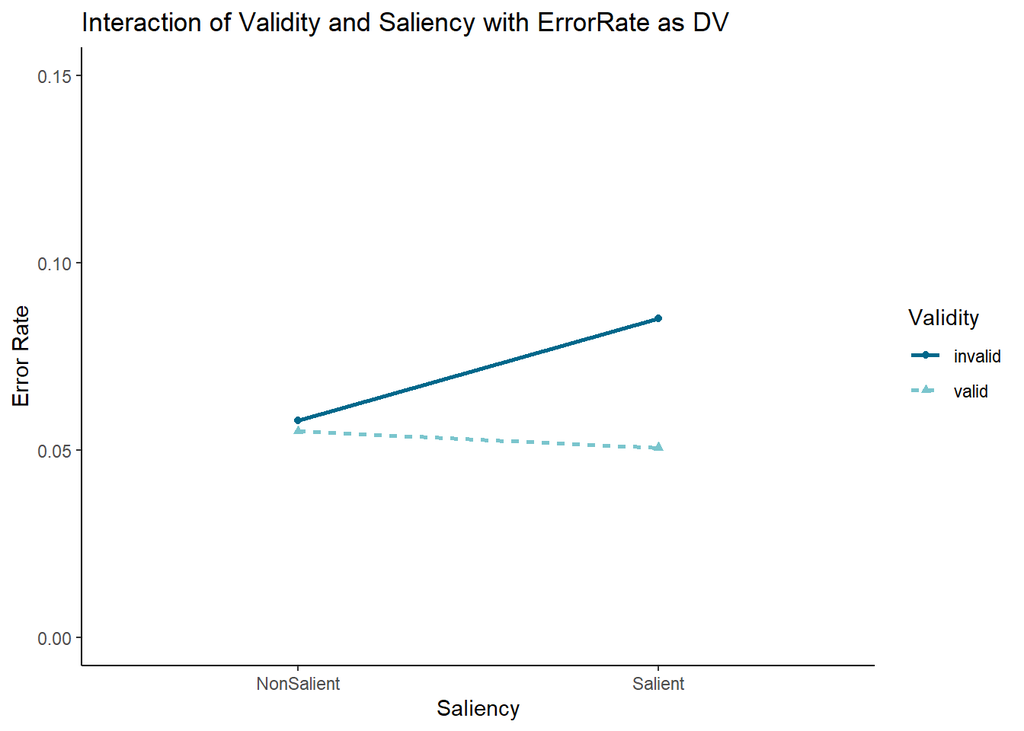

### 5. Inverse Efficiency scores

Given the trends seen in RTs and Error Rate, the inverse Efficiency score was computed and used as a dependant variable. IES = RT/(1 - ErrorRate)

- **ANOVA**:

  | Effect | DFn | DFd | SSn | SSd | F | p | p<.05 | ges |
  | --- | --- | --- | --- | --- | --- | --- | --- | --- |
  | (Intercept) | 1 | 69 | 102702970 | 1206567 | 5873 | 1.668e-68 | * | 0.9825 |
  | Saliency | 1 | 69 | 4063 | 148341 | 1.89 | 0.1736 |  | 0.00221 |
  | Validity | 1 | 69 | 50222 | 221739 | 15.63 | 0.0001841 | * | 0.02665 |
  | Saliency:Validity | 1 | 69 | 8260 | 257910 | 2.21 | 0.1417 |  | 0.004482 |

```
## $`--- ANOVA RESULTS     ------------------------------------`
##              Effect       MSE df1 df2       F     p petasq getasq
## 1       (Intercept) 17486.480   1  69 5873.28 0.000   0.99   0.98
## 2          Saliency  2149.876   1  69    1.89 0.174   0.03   0.00
## 3          Validity  3213.615   1  69   15.63 0.000   0.18   0.03
## 4 Saliency:Validity  3737.822   1  69    2.21 0.142   0.03   0.00
##
## $`--- SPHERICITY TESTS  ------------------------------------`
## [1] "N/A"
##
## $`--- FORMATTED RESULTS ------------------------------------`
##              Effect                                    Text
## 1       (Intercept) F(1, 69) = 5873.28, p < .001, np2 = .99
## 2          Saliency F(1, 69) =    1.89, p = .174, np2 = .03
## 3          Validity F(1, 69) =   15.63, p < .001, np2 = .18
## 4 Saliency:Validity F(1, 69) =    2.21, p = .142, np2 = .03
##
## $`NOTE:`
## [1] "Reporting unadjusted p-values."
```

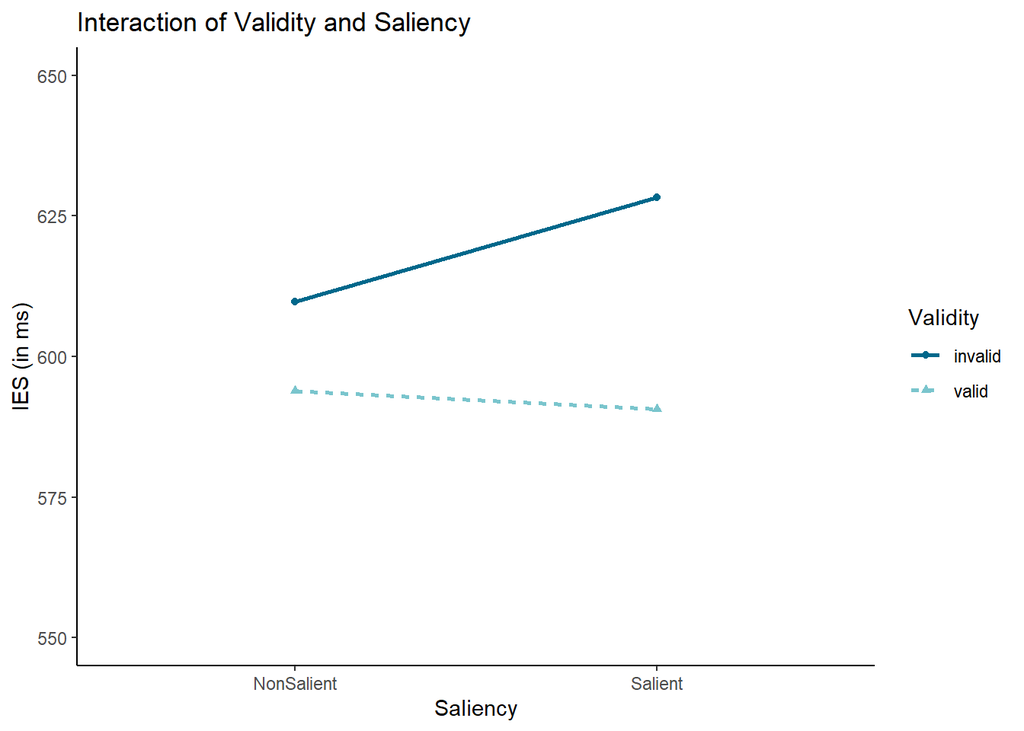

Mean IES score validity effect

| Saliency | N | Mean | SD | FLSD |
| --- | --- | --- | --- | --- |
| NonSalient | 70 | 15.92 | 72.37 | 29.16 |
| Salient | 70 | 37.65 | 93.09 | 29.16 |

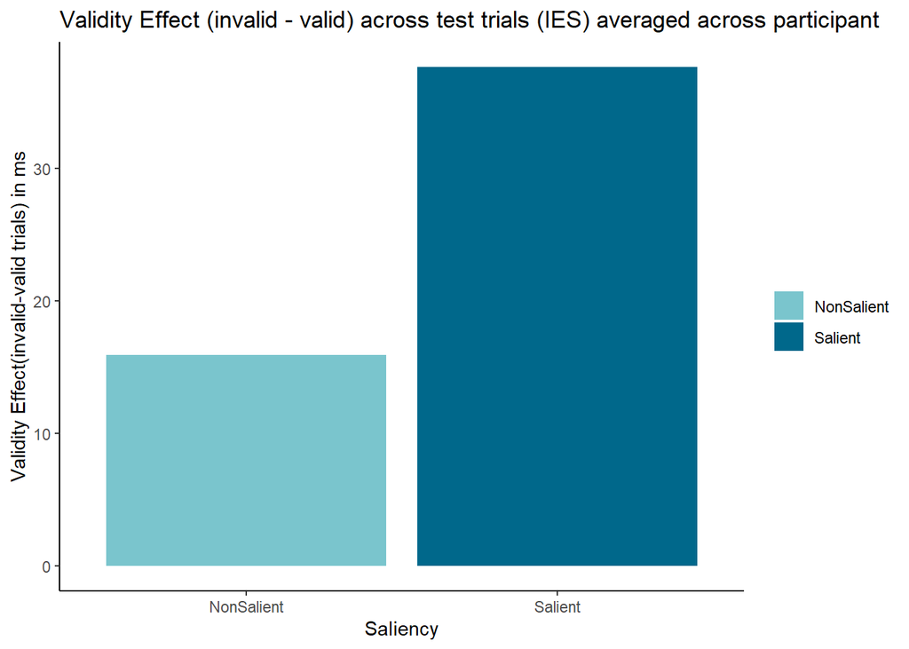

Are these validity effects significant?